# Wilson Disease Data Analysis

Jyotishka Datta

January 1, 2020

## Background and Motivation

### Simple Descriptive Statistics

First, we report the basic descriptive statistics for the numerical variables. Note that some of the covariates are ordinal in nature, they are not reported on Table 1.

### Descriptive Statistics

**df**  
**N:** 52

|  | Mean | Std.Dev | Min | Max |
| --- | --- | --- | --- | --- |
| **AgeAtDx** | 13.96 | 5.66 | 5.00 | 33.00 |
| **CERU** | 12.24 | 4.03 | 4.00 | 23.00 |
| **FABScore** | 10.63 | 2.55 | 4.00 | 16.00 |
| **MMSE** | 23.74 | 4.10 | 12.00 | 33.00 |

#### Correlation

Figure 1 shows the scatter plot as well as the correlation between the numerical variables. In particular, it shows:

1. The distributions for each variable.
2. Scatter plots with a fitted line.
3. The value of correlation.

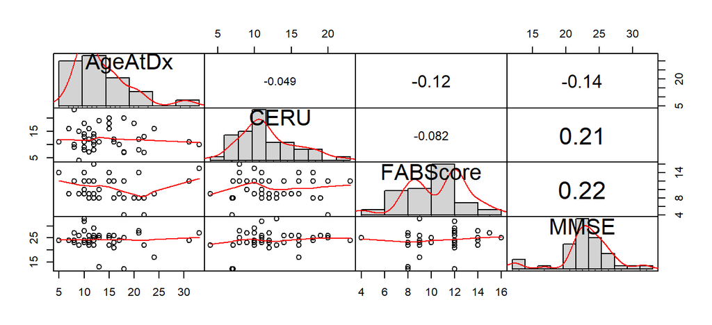

Correlation Chart

#### Association between factors

Here we show the association between the factors in our data, measured by the Chi-square p-value as well as the Cramer’s V. We split the association matrix into two halves for the sake of presentation, with ‘Common Mutation’ being the common variable on both the plots. The first figure suggests strong association between different clinical variables but not so much with Common Mutation, and the second figure suggests some association of Common Mutation with Parkinsons, Dystonia, Depression and Gait.

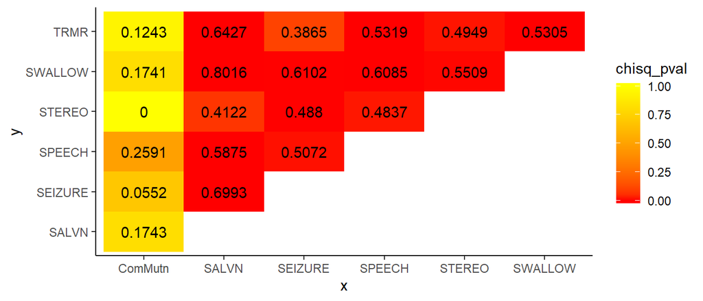

Association measures: chi-square and Cramer’s V. Part 1

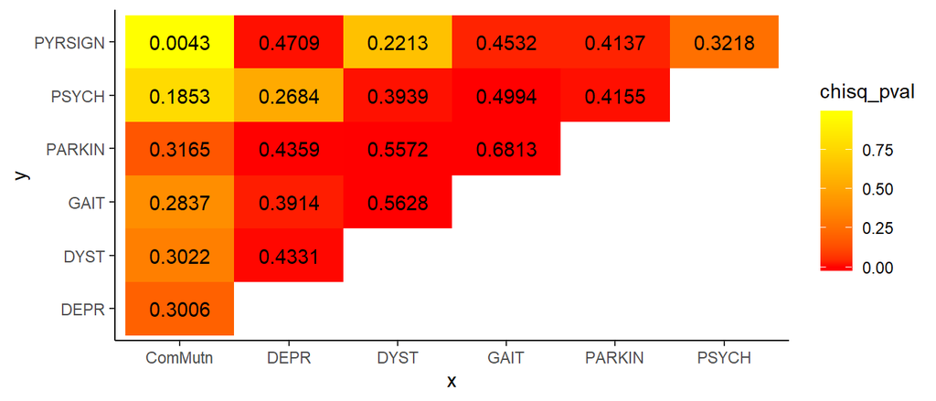

Association measures: chi-square and Cramer’s V. Part 2

#### Comparison across subgroups

Figure 4-7 show how the four numerical variables viz. Age at diagnosis, Ceruloplasmin, MMSE (cognitive scale), and Fab scores. It seems from these box-plots that the differences for these variables between different levels of Common mutation are not significant, indicated by the substantial overlap of the probability regions.

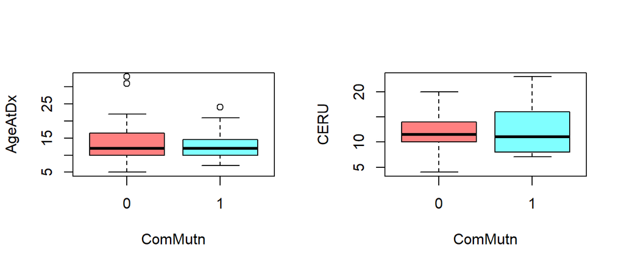

Boxplots for subgroup analysis: Age & Ceruloplasmin

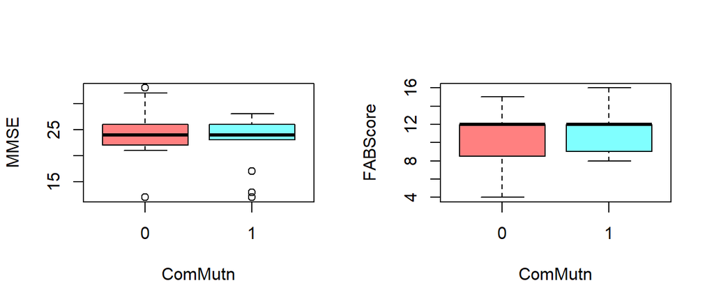

Boxplots for subgroup analysis: MMSE

## Classification of Common Mutation using Clinical Variables

### Brief Review: Supervised Learning

We take a supervised learning approach to evaluate the performance of the penalized logistic regression to predict common mutation. The key idea behind supervised learning algorithm is to divide the data into two halves - training samples and test samples, and fit the model on one half (training samples) and evalue its performance such as prediction or inference on the remaining half: the test data.

Supervised learning prevents overfitting - a phenomenon that happens when with increasing model complexity the training error is monotonically reduces and at some point the model starts fitting to the noise patterns. Such a over-complex model can not generalize to unseen data and deteriorates performance even when samples from the same data generating mechanism is fed into the system. In order to prevent this, we fit the model on the training samples: in our context, this means we estimate the parameters of the logistic regression by minimizing the error from the training samples via cross-validation and the performance is reported on the test data.

### Penalized Logistic Regression

We want to fit a logistic regression model for explaining Common Mutation as a function of the available predictors. A logistic regression fits the log-odds of the probabilities as a linear function of the predictors, i.e.

$$\eta_i = \log(\frac{p_i}{1-p_i}) = \alpha + \sum_{j=1}^{p} x_{ij}\beta_j , \; i = 1, \ldots, n,$$
where the $x_{ij}$ is the i-th observation for the j-th predictor.

The usual regression approach would run into a problem here as we have a low-rank data. Here $n = 52$, but the number of predictors is more than the number of columns in our data frame, as each ordinal factor has to be recoded into a baseline category, and one predictor for each different level.

The solution to this is to use a penalized regression such as the Elastic net. The elastic net regression minimizes the penalized log-likelihood

$$S = -l(y,\beta) + P_{\lambda,\alpha}(\beta),$$

where $l(y,\beta)$ is the log-likelihood and $P_{\lambda,\alpha}(\beta)$ is the penalty term. For the logistic regression the log-likelihood is given by:

$$l(y,\beta) = \sum_{i=1}^{n} y_i \log(p_i) +\sum_{i=1}^{n}(1-y_i)\log(1-p_i)$$
and the Elastic net penalty term is given by:

$$P_{\lambda,\alpha}(\beta) = \lambda \left \{ \frac{(1-\alpha)}{2} {\lVert \beta \rVert}_2^2 + \alpha {\lVert \beta \rVert}_1^2 \right \}$$
We can use the same R package ‘glmnet’ with family = “gaussian” to family=“binomial” for implementing the penalized logistic regression.

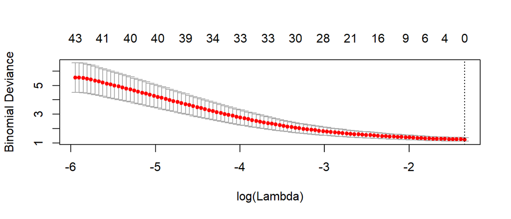

Elastic Net with Binomial Likelihood

The plot shows the deviance (a goodness-of-fit statistic) as a function of the tuning parameter $\lambda$, and the number of variables in the model (top margin of the plot). *It shows that at the optimal value, Elastic net selects no variables at all, or in other words, fits the null model.*

Since our goal is to understand the relative importance of predictors in explaining common mutation, we can look at a smaller value of $\lambda$ (we take $\lambda = 0.1$ here) on the coefficient path, and see which predictors come out on the top. This will not be a powerful predictive model but can give us some insgights into their relationships.

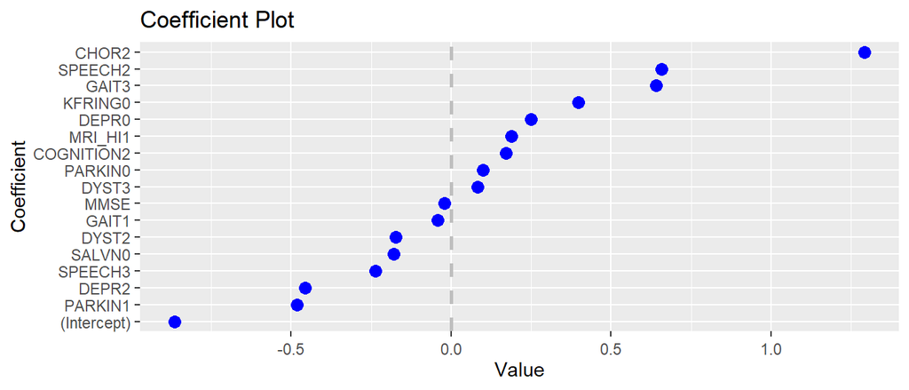

Coefficients for Penalized Logistic Regression

### Random Forest

The random forest (Breiman, 1996), on the other hand, is an ensemble method where many classification and regression trees are grown on resamples of the training data (i.e. bootstrapped samples), and finally an average is taken over the predictions from each individual trees, with a clever strategy to decorrelate the trees. For a single regression tree method, a large decision tree is grown depending on space partitions of the predictor space that yields a small residual sum of squares on training data. To fix ideas, suppose we consider $T$ different regions of the predictor space, say $R_1, R_2, \ldots, R_T$, and the average value of the response for the $j^{th}$ region is $\hat{y}_{R_j}$: then a regression tree with attempts to find a sub-tree that minimizes an objective function:

$$\sum_{j=1}^{|T|} \sum_{i: x_i \in R_j} (y_i - \hat{y}_{R_j})^2 + \alpha |T|.$$

The first half of this expression is the residual sum of sqaures on training samples and the second half is a penalty term that prevents over-fitting by controlling the size of the tree; thus improving test error in unobserved samples. A random forest is an ensemble of such trees, each grown on bootstrapped training samples, but with a clever trick that decorrelates the trees. For each split of each trees grown in the forest, only a subset $m$ of the $p$ predictors is allowed to be considered as split variables (typically $m = \sqrt{p}$). This prevents all trees in the ensemble looking very similar, which leads to an improvement by reducing the variance. Since a random forest is the ensemble of many space-partitioning trees, these models tend to be better suited when the relationships are non-linear in nature.

### Random Forest: Variable importance

Next, we try to get under the hood of the model. We do this first, by visualizing variable importance. The below plot visualizes ‘feature importance’ for the Random Forest sub-model, showing which features make the greatest contribution in predicting common mutation. For a random forest classifier, Gait and Age at Dx has the greatest contribution, followed by Dyst and Depr. The order of importance is not the same as that from the *logistic* regression model, which is expected since the random forest fits a space-partitioning model instead of a linear model. We caution the reader to consider these relationships the result of correlation, not causation.

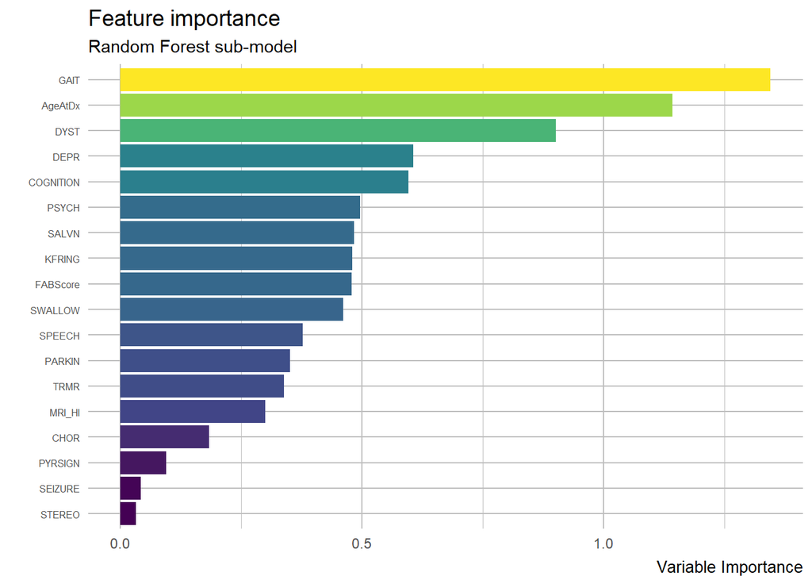

### Performance on Test Data

This section shows the relative performance of the two methods: logistic regression and random forest. The first two tables show the predicted class labels versus the true class labels.

#### Random Forest

Classification by Random Forest

|  | True Class Labels Test Data 0 | True Class Labels Test Data 1 |
| --- | --- | --- |
| **Predicted Class Labels** |  |  |
| 0 | 12 | 8 |
| 1 | 5 | 1 |

Misclassification Probability for Random Forest 0.5

#### Logistic Regression

Classification Performance

|  | True Class Labels Test Data 0 | True Class Labels Test Data 1 |
| --- | --- | --- |
| **Predicted Class Labels** |  |  |
| 0 | 15 | 9 |
| 1 | 2 | 0 |

Misclassification Probability for Logistic Regression 0.4230769

The misclassification probability for the logistic regression and the random forest are 0.4230769 and 0.5 respectively. A number close to 1/2 is almost as bad as a random guess that has a misclassification probability of 1/2. From the tables, it seems the prediction for either methods misses most or all the labels with true value “1”, and vice versa, i.e. the predicted values with label “1” are incorrectly classified. This is not surprising since the elastic net model was not able to find any strongly correlated predictors.

#### ROC Curve

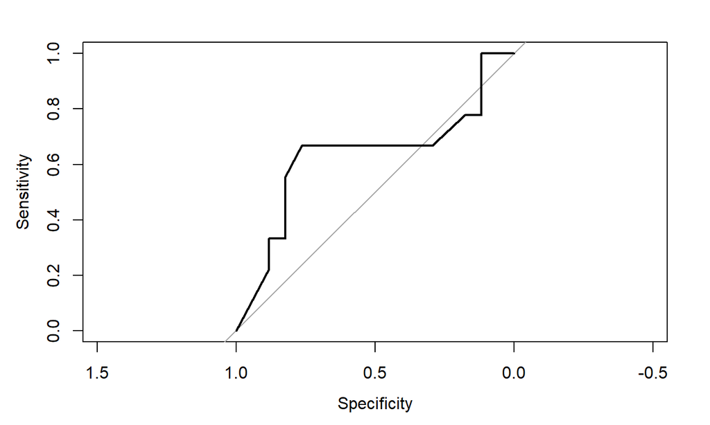

## Appendix

### Predicted Probabilities from GLM

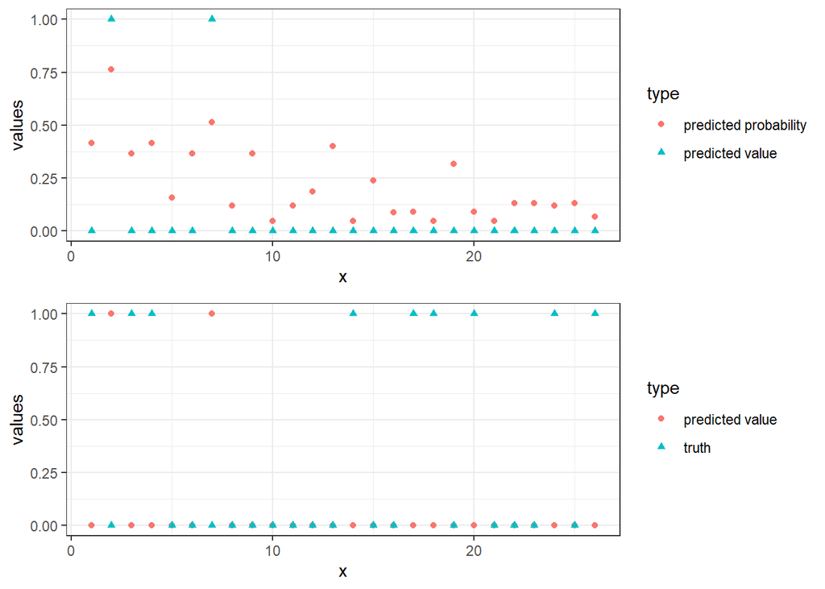

The first panel on the figure shows the predicted probabilities and the actual prediction and the second shows the true labels vs the prediction.